# Uncertainty and Monte Carlo

Lecture 08

September 23, 2024

# Review of Last Classes

## Simulation

- “Mimic” data generation given a certain model for the relevant processes;
- Often requires some type of discretization (not always!)

## Simulation Workflow

[figure not shown]

Simulation Workflow

## Simulation

- “Mimic” data generation given a certain model for the relevant processes;
- Often requires some type of discretization (not always!)
- More complex approaches (*e.g.* discrete-event simulation) for specific use cases.

## What We Haven’t Discussed

- **Calibration**: How do we select parameter values?
- **Validation**: Does the model adequately reproduce the system dynamics?

## Dissolved Oxygen

- Dissolved oxygen (DO) is essential for water quality and aquatic life.
- Commonly regulated to keep DO above a minimum threshold.
- DO impacted by a number of factors, notably organic waste decomposition and nitrification.
- “Sag Curve”: DO reduced near a discharge until waste decomposition reduces OD and re-aeration can occur.

## Questions?

[figure not shown]

**Text**: VSRIKRISH to 22333

**URL**: https://pollev.com/vsrikrish  
[See Results](https://www.polleverywhere.com/multiple_choice_polls/qKeig0hHShZYHAOmvZtZm?preview=true&controls=none)

# Uncertainty and Systems Analysis

## Systems and Uncertainty

- *Deterministic models*: uncertainty due to the separation between the “internals” of the system and the “external” environment.
- *Stochastic models*: additional uncertainty from internal stochasticity

[figure not shown]

Conceptual Schematic of a Systems Model

## What is Uncertainty?

**Glib Answer**: *A lack of certainty!*

**More Seriously**: Uncertainty refers to an inability to exactly describe current or future values or states.

## Types of Uncertainty

Two (broad) types of uncertainties:

- **Aleatory** uncertainty, or uncertainties resulting from randomness;
- **Epistemic** uncertainty, or uncertainties resulting from lack of knowledge.

# Risk

## Systems and Risk

Designing and managing environmental systems is often about **minimizing or managing risk**:

- Maintaining clean air/water;
- Power grid reliabiliy standards;
- Flooding/other hazards;
- Climate change mitigation/adaptation.

## What is Risk?

The [*Society for Risk Analysis* definition](https://www.sra.org/wp-content/uploads/2020/04/SRA-Glossary-FINAL.pdf):

> “risk” involves uncertainty about the effects/implications of an activity with respect to something that humans value (such as health, well-being, wealth, property or the environment), often focusing on negative, undesirable consequences.

## So What is Risk?

**Important**: “Risk” is not just another words for probability, but:

- Involves uncertainty;
- Undesireable outcomes;
- Effects matter, not just the events themselves.

## Components of Risk

Multiple components which contribute to risk:

- Probability of a **hazard**;
- **Exposure** to that hazard;
- **Vulnerability** to outcomes;
- Socioeconomic **responses**.

[figure not shown]

Overview of the Components of Risk

Source: [Simpson et al (2021)](https://doi.org/10.1016/j.oneear.2021.03.005)

## Systems and Risk Management

Risk management is often a key consideration in systems analysis. For example, consider regulatory standards.

- Often a tradeoff between strictness of a regulation and costs of compliance.
- Systems modeling is a key way to understand
  - the impacts of changing a regulation
  - the probability of failure to meet standards.

# Probability

## Two Definitions of Probability

We often represent uncertainties with *probabilities*. What is a probability?

1. Long-run frequency of an event (**frequentist**)
2. Degree of belief that a proposition is true (**Bayesian**)

## Conditional Probabilities

We often don’t want to just know if a particular event $A$ has a certain probability, but also how other events (call them $B$) might depend on that outcome.

**In other words:**

We want the *conditional probability* of $B$ given $A$, denoted $\mathbb{P}(B|A)$.

## Conditional Probabilities

We can write conditional probabilities in terms of unconditional probabilities:

$$\mathbb{P}(B|A) = \frac{\mathbb{P}(BA)}{\mathbb{P}(A)}.$$

## Probability Distributions

The probability of possible values of an unknown quantity are often represented as a probability distribution.

Probability distributions associate a probability to every event under consideration (the *event space*) and have to follow certain rules (for example, total probability = 1).

## Selecting a Distribution

The specification of distributions can *strongly* influence the analysis.

[figure not shown]

Probabilistic interactions between sea-levels and exposure

## Selecting a Distribution

A distribution implicitly answers questions like:

- What is the most probable event? How much more likely is it than the others?
- Are larger or smaller events more, less, or equally probable?
- How probable are extreme events?
- Are different events correlated, or are they independent?

## Key Features of Probability Distributions

- Mean/Mode (what events are “typical”)
- Skew (are larger or smaller events more or equally probable)
- Variance (how spread out is the distribution around the mode)
- Tail Probabilities (how probable are extreme events)

## Common Distributions

- Gaussian / Normal
- Lognormal
- Binomial
- Uniform / Discrete Uniform

## Probability Distribution Tails

The tails of distributions represent the probability of high-impact outcomes.

**Key consideration**: Small changes to these (low) probabilities can greatly influence risk.

[figure not shown]

# Monte Carlo

## Stochastic Simulation

**Monte Carlo simulation**: Propagating random samples through a model to estimate a value (usually an expectation or a quantile).

[figure not shown]

## Goals of Monte Carlo

Monte Carlo is a broad method, which can be used to:

1. Obtain probability distributions of outputs;
2. Estimate deterministic quantities (*Monte Carlo estimation*).

## Monte Carlo Estimation

Monte Carlo estimation involves framing the quantity of interest as a summary statistic (such as an expected value).

## MC Example: Finding $\pi$

Finding $\pi$ by sampling random values from the unit square and computing the fraction in the unit circle. This is an example of **Monte Carlo integration**.

$$\frac{\text{Area of Circle}}{\text{Area of Square}} = \frac{\pi}{4}$$

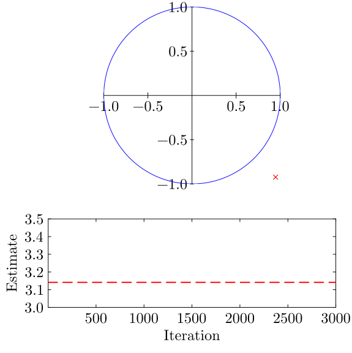

Figure 1: Monte Carlo simualtion for Estimating pi

## MC Example: Dice

What is the probability of rolling 4 dice for a total of 19?

Can simulate dice rolls and find the frequency of 19s among the samples.

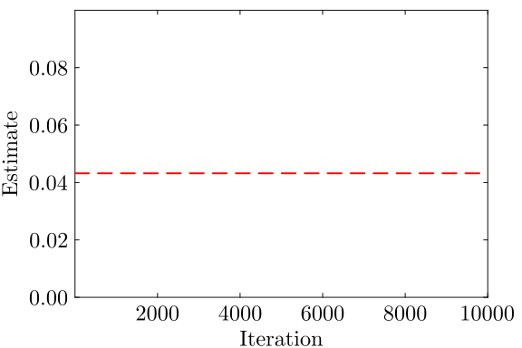

Figure 2: Monte Carlo simualtion for Dice Rolls

## Monte Carlo Estimation

This type of estimation can be repeated with any simulation model that has a stochastic component.

For example, consider our dissolved oxygen model. Suppose that we have a probability distribution for the inflow DO.

**How could we compute the probability of DO falling below the regulatory standard somewhere downstream?**

## Monte Carlo and Uncertainty Propagation

1. Draw samples from some distribution;
2. Eun them through one or more models;
3. Compute the (conditional) probability of outcomes of interest (for good or bad).

# Key Takeaways

## Key Takeaways

- Systems analysis features many uncertainties, which may be neglected with certain methods/model setups.
- Choice of probability distribution can have large impacts on uncertainty and risk estimates: **try not to use distributions just because they’re convenient.**
- **Monte Carlo**: Estimate expected values of outcomes using simulation.

# Upcoming Schedule

## Next Classes

**Wednesday**: Monte Carlo Lab (clone before class, maybe instantiate environment too)

**Monday**: Why Does Monte Carlo Work?

## Assessments

**HW3**: Released today, due 10/03 at 9pm.